# Weather, Location, and Scoring in the NFL: A Statistical Analysis of the 2013 Season

Dylan Escano, Jack Curtin, Brady Monturio”

2025-10-07

## Executive Summary

Our project looked into how weather affects NFL performance through different variables such as wind speed, temperature, stadium type, and home field advantage. We used NFL data from the 2013 season. We applied statistical methods like maximum likelihood estimates, regression models, and visualizations to identify potential trends, and determine the effect of weather on game outcomes.

## Key Findings:

- Temperature and wind speed had minimal effect on scoring.
- Home teams won 61.5% of games, suggesting some advantage.
- Games in domes saw slightly higher scoring, but the difference was not statistically significant.
- Environmental factors explained very little of the variation in total points.

  Our analysis suggests that while teams may adjust strategies based on weather, these factors do not strongly determine game score. Home field advantage is small, and not statistically sound enough to conclude any significant difference.

## Introduction

American football is the most popular sport in the United States. Generating over $23 billion in the last fiscal year, the sport is very popular, drawing in fans from all around the globe. Fans take games very seriously, and multiple factors contribute to winning a game. Some industries are very interested in predicting the outcomes of games, such as the sports betting industry, which generates billions of dollars each year. Without a doubt, coaching, training, team culture, and injuries contribute to the outcome of games. Other factors that can contribute to the outcomes of games are whether or not it is a home game (teams playing at home may have a slight advantage due to familiarity and being backed by more fans), simple luck, and weather. It is not always clear how the weather affects the outcome of games. As the sport of football and many other sports grow more data-driven, understanding the impact of external factors has become even more important. One of the least predictable and least understood variables is weather. Unlike fixed elements like team rosters or stadium location, weather conditions can change quickly and vary each game. Rain, snow, wind, or extreme temperatures can alter game strategy, player performance, and even increase risk of injury. For this project, my team and I will seek to determine how significant the weather is in the outcome of NFL games.

## Data and Methods

### We analyzed data from the 2013 NFL regular season games. The dataset included:

- Scores (away team & home team).
- Weather-specific variables (temperature, wind speed, humidity)
- Team-specific and stadium-specific variables (home/away team, outdoor vs. indoor stadium).

### Before Analysis Steps:

- Calculated total points for each game.
- Converted weather data into numerical format.
- Removed rows with missing values.

### Statistical Methods Used:

- Descriptive statistics (means, histograms)
- Linear regression models to evaluate relationships between variables
- Correlation analysis
- Data visualizations using histograms and scatter plots

```r
# import needed data

nfl_data <- read_csv("nfl.csv")

# Clean humidity column
nfl_data$humidity <- as.numeric(gsub("%", "", nfl_data$humidity))

# Create total points
nfl_data$total_points <- nfl_data$home_score + nfl_data$away_score

# Remove NAs
nfl_clean <- na.omit(nfl_data)


# Average temperature and average total points
avg_temp <- mean(nfl_clean$temperature)
avg_score <- mean(nfl_clean$total_points)
avg_wind <- mean(nfl_clean$wind_mph)


avg_summary <- tibble(
  `| Average Temperature (°F) |` = round(avg_temp, 2),
  `| Average Total Points |` = round(avg_score, 2),
  `| Average Wind Speed |` = round(avg_wind,2)
)
knitr::kable(avg_summary, caption = "")
```

| \| Average Temperature (°F) \| | \| Average Total Points \| | \| Average Wind Speed \| |
| --- | --- | --- |
| 59.63 | 45.99 | 9.24 |

```r
library(MASS)


# Fit a normal distribution to total points using MLE
fit_mle <- fitdistr(nfl_clean$total_points, "normal")

# Extract estimates
mle_mean <- round(fit_mle$estimate["mean"], 2)
mle_sd <- round(fit_mle$estimate["sd"], 2)

# Create a small results table
mle_table <- tibble(
  `Estimated Mean (μ)` = mle_mean,
  `Estimated SD (σ)` = mle_sd
)

# Print the MLE estimates
knitr::kable(mle_table, caption = "Maximum Likelihood Estimates for Total Points Distribution")
```

Maximum Likelihood Estimates for Total Points Distribution

| Estimated Mean (μ) | Estimated SD (σ) |
| --- | --- |
| 45.99 | 14.69 |

Using maximum likelihood estimation, we found that the distribution of total points scored per NFL game in 2013 had an estimated mean of 45.99 points and a standard deviation of 14.69. This supports the idea that scoring was fairly consistent across games, with most games falling within a predictable range of outcomes. The results also suggest that total points roughly follow a normal distribution, making it appropriate to use linear regression in our analysis.

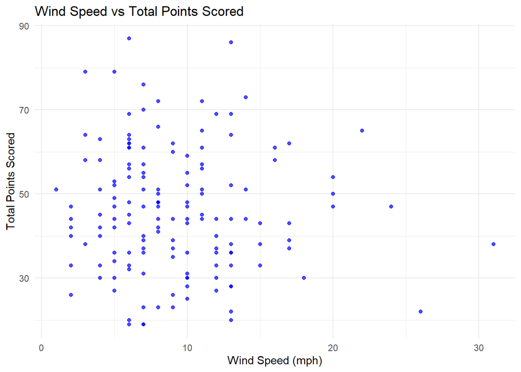

```r
ggplot(nfl_clean, aes(x = wind_mph, y = total_points)) +
  geom_point(alpha = 0.7, color = "blue") +
  labs(title = "Wind Speed vs Total Points Scored",
       x = "Wind Speed (mph)",
       y = "Total Points Scored") +
  theme_minimal()
```

```r
wind_score_correlation <- cor(nfl_clean$wind_mph, nfl_clean$total_points)


cor_table <- tibble(
  `Correlation Between Wind and Total Points` = round(wind_score_correlation, 4)
)

knitr::kable(cor_table, caption = "")
```

| Correlation Between Wind and Total Points |
| --- |
| -0.059 |

```r
# Fit model
wind_model <- lm(total_points ~ wind_mph, data = nfl_clean)

# Get summary components
wind_summary <- summary(wind_model)
r2 <- round(wind_summary$r.squared, 4)

# Build coefficient table
wind_table <- as_tibble(wind_summary$coefficients, rownames = "Variable")
colnames(wind_table) <- c("| Variable| ", "| Estimate |", "| Std. Error |", "| t value |", "| p value |")
wind_table <- wind_table %>% mutate(across(where(is.numeric), round, 4))

# Add R² column (same for all rows)
wind_table$R2 <- r2

print(wind_table)
```

```
## # A tibble: 2 × 6
##   `| Variable| ` `| Estimate |` `| Std. Error |` `| t value |` `| p value |`
##   <chr>                   <dbl>            <dbl>         <dbl>         <dbl>
## 1 (Intercept)            47.6              2.58         18.5           0
## 2 wind_mph               -0.176            0.246        -0.714         0.477
## # ℹ 1 more variable: R2 <dbl>
```

```r
knitr::kable(wind_table, caption = "Wind Regression Model")
```

Wind Regression Model

| \| Variable\| | \| Estimate \| | \| Std. Error \| | \| t value \| | \| p value \| | R2 |
| --- | --- | --- | --- | --- | --- |
| (Intercept) | 47.6110 | 2.5800 | 18.4541 | 0.0000 | 0.0035 |
| wind_mph | -0.1758 | 0.2463 | -0.7135 | 0.4767 | 0.0035 |

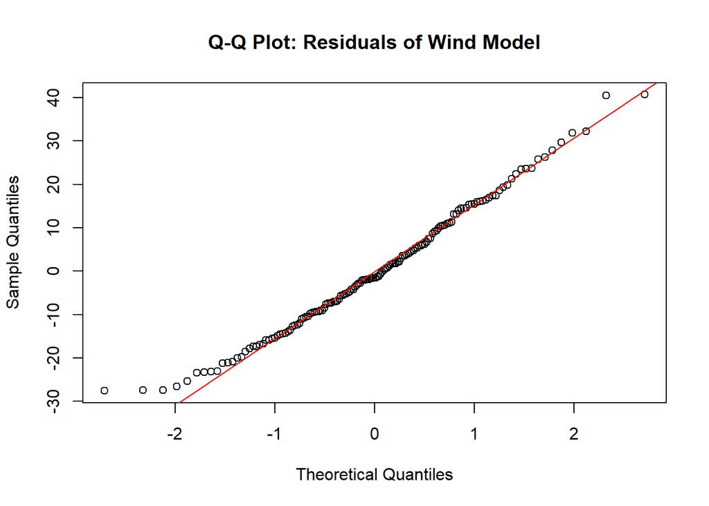

```r
# Q-Q Plot of Residuals
qqnorm(residuals(wind_model), main = "Q-Q Plot: Residuals of Wind Model")
qqline(residuals(wind_model), col = "red")
```

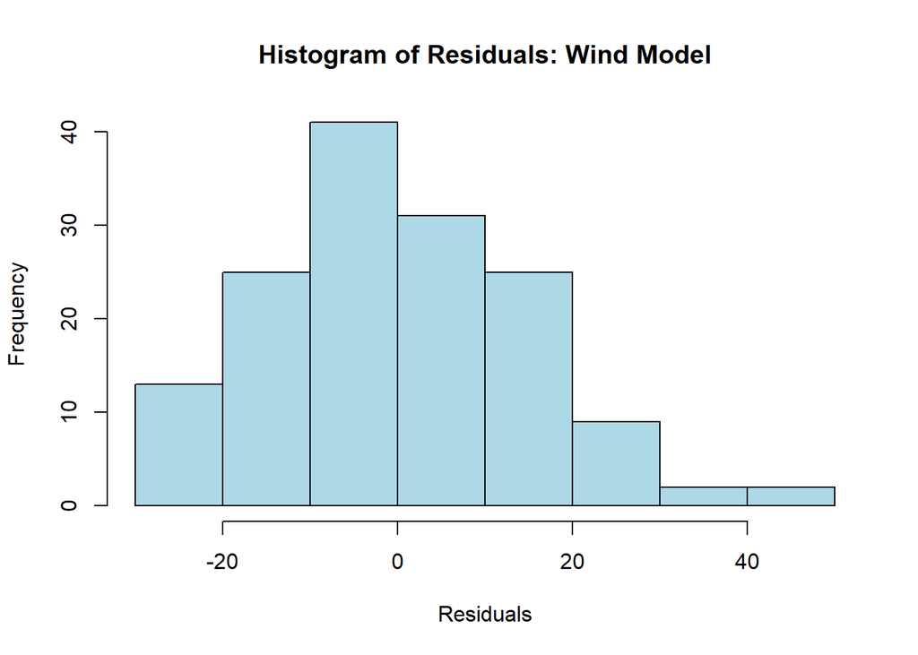

```r
# Histogram of Residuals
hist(residuals(wind_model),
     main = "Histogram of Residuals: Wind Model",
     xlab = "Residuals",
     col = "lightblue",
     border = "black")
```

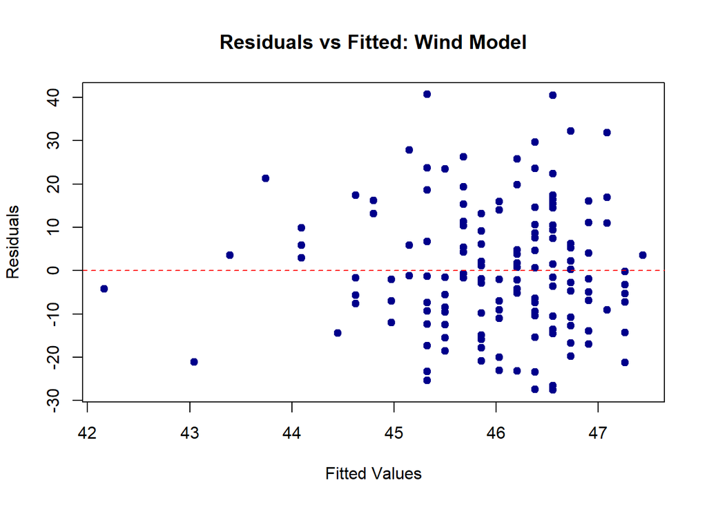

```r
# Residuals vs Fitted Values
plot(fitted(wind_model),
     residuals(wind_model),
     main = "Residuals vs Fitted: Wind Model",
     xlab = "Fitted Values",
     ylab = "Residuals",
     pch = 19,
     col = "darkblue")
abline(h = 0, col = "red", lty = 2)
```

The diagnostic plots suggest that the linear regression model meets key assumptions. The Q-Q plot shows that residuals are approximately normally distributed, and the histogram supports this with a fairly symmetric shape. The residuals vs fitted values plot reveals no clear patterns, indicating consistent variance and a reasonable fit. While the model doesn’t explain much of the variation in total points, the assumptions of linear regression appear to be satisfied.

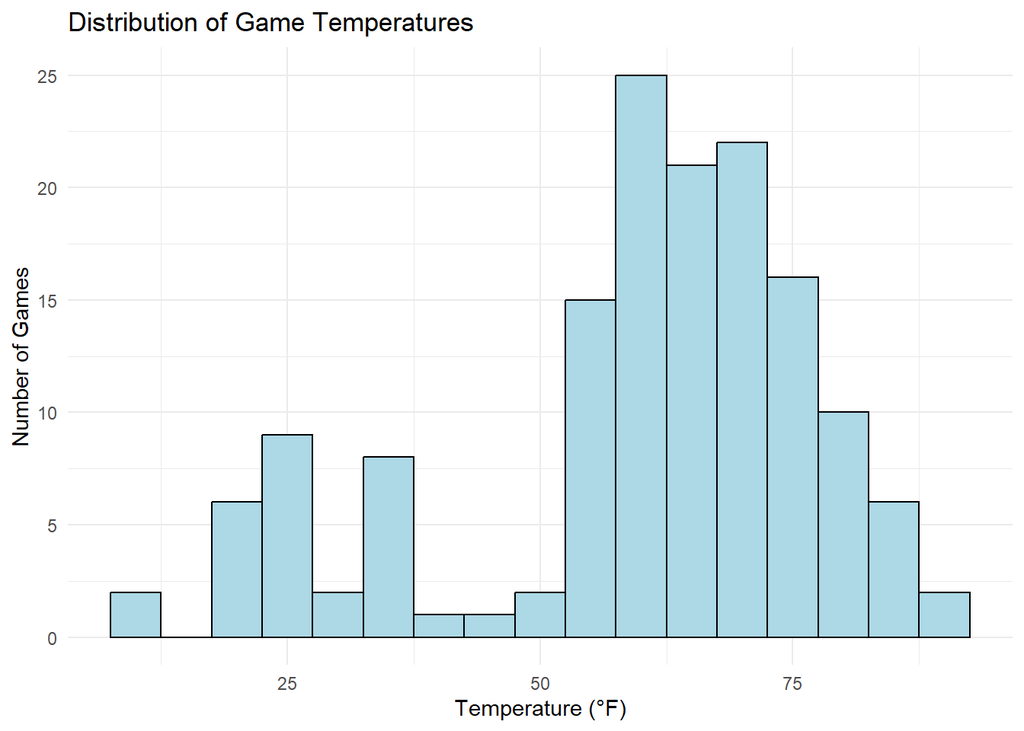

```r
ggplot(nfl_clean, aes(x = temperature)) +
  geom_histogram(binwidth = 5, fill = "lightblue", color = "black") +
  labs(title = "Distribution of Game Temperatures",
       x = "Temperature (°F)",
       y = "Number of Games") +
  theme_minimal()
```

The histogram shows that the majority of NFL games during the 2013 season were played when the temperature ranged between 55 and 70 degrees Fahrenheit. This distribution is expected because the NFL season takes place during fall and early winter, and many games are played in moderate climates. Extremely cold or hot games were rare but not unheard of.

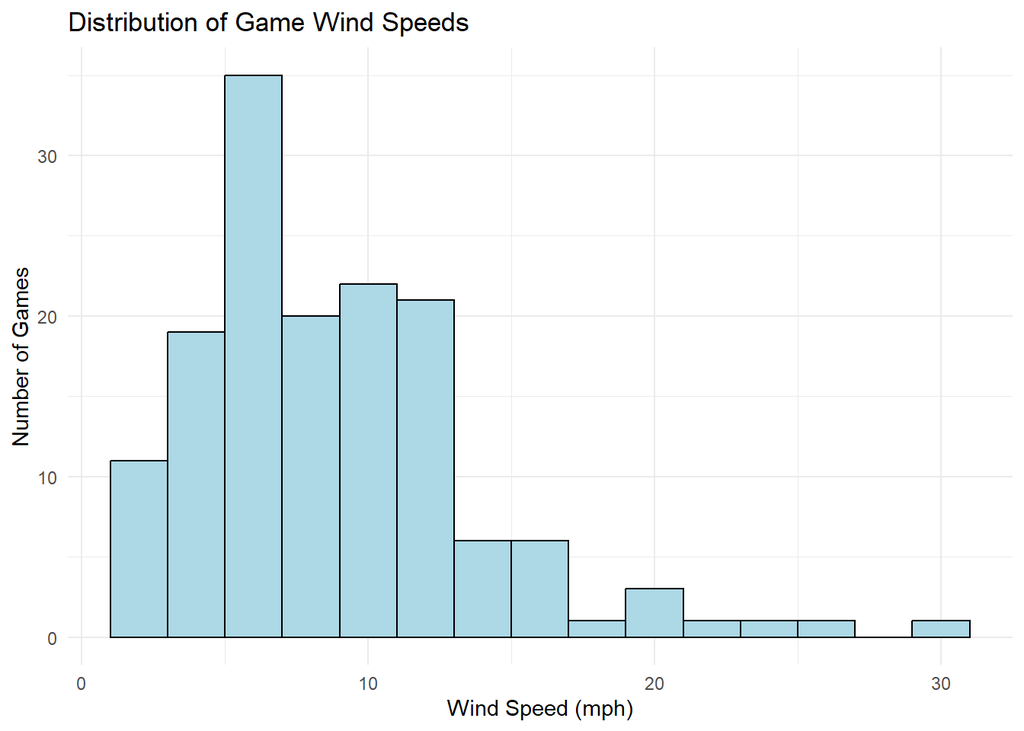

```r
ggplot(nfl_clean, aes(x = wind_mph)) +
  geom_histogram(binwidth = 2, fill = "lightblue", color = "black") +
  labs(title = "Distribution of Game Wind Speeds",
       x = "Wind Speed (mph)",
       y = "Number of Games") +
  theme_minimal()
```

This histogram shows that most NFL games in the 2013 season were played in relatively calm conditions, with wind speeds clustering between 0 and 15 mph. High-wind games were much less common, which makes sense given that many stadiums are either partially enclosed or located in milder climates. Overall, extreme wind was a rare factor.

### How Much of an Impact Does Home Field Advantage Make?

```r
nfl_clean$home_win <- nfl_clean$home_score > nfl_clean$away_score

home_win_percentage <- mean(nfl_clean$home_win) * 100

nfl_clean$away_win <- nfl_clean$away_score > nfl_clean$home_score
away_win_percentage <- mean(nfl_clean$away_win) * 100

home_win_table <- tibble(
  `Home Win Percentage ` = paste0(round(home_win_percentage, 2), "%"), ` Away Win Percentage ` = paste0(round(away_win_percentage, 2), "%"))

knitr::kable(home_win_table, caption = "")
```

| Home Win Percentage | Away Win Percentage |
| --- | --- |
| 61.49% | 37.84% |

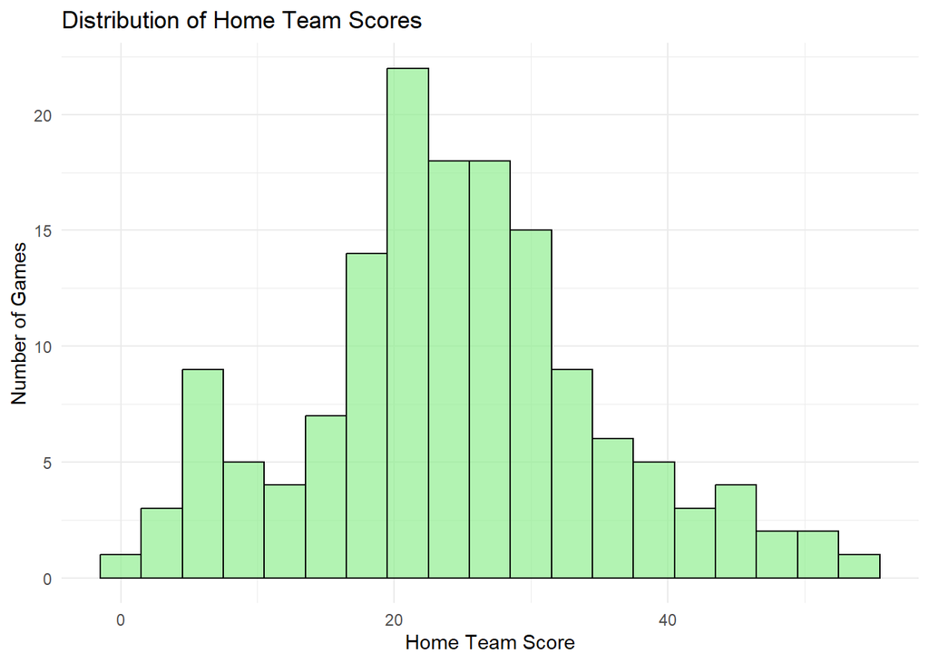

```r
# Histogram of home team scores
ggplot(nfl_clean, aes(x = home_score)) +
  geom_histogram(binwidth = 3, fill = "lightgreen", color = "black", alpha = 0.7) +
  labs(title = "Distribution of Home Team Scores",
       x = "Home Team Score",
       y = "Number of Games") +
  theme_minimal()
```

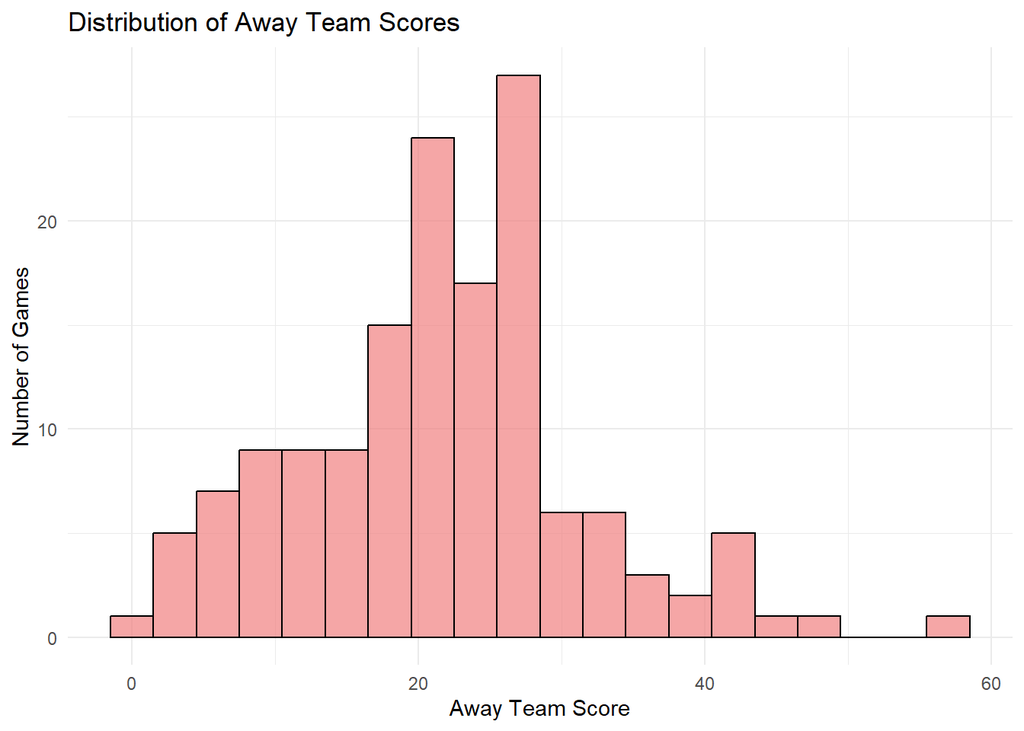

```r
# Histogram of away team scores
ggplot(nfl_clean, aes(x = away_score)) +
  geom_histogram(binwidth = 3, fill = "lightcoral", color = "black", alpha = 0.7) +
  labs(title = "Distribution of Away Team Scores",
       x = "Away Team Score",
       y = "Number of Games") +
  theme_minimal()
```

Home teams won approximately 61.49 percent of the games, while away teams won approximately 37.84 percent of the games during the 2013 season. This suggests that playing at home provides a real advantage, likely due to factors such as crowd support, reduced travel, and familiarity with the stadium. However, while helpful, home field advantage is not an overwhelming guarantee of winning.

#### Why the Home Field Advantage Conclusion Might Be Misleading

Although the home team won about 62 percent of the time, this statistic does not prove that location alone caused the wins. Stronger teams often have better regular season records and get to host more home playoff games, which could inflate the win percentage. Other variables such as overall team strength, injuries, and coaching decisions play important roles and may be more influential than simply playing at home.

The histograms of home team scores and away team scores show that home teams tended to score slightly more points than visiting teams during the 2013 season. While the overall shapes of the distributions were similar, the slight rightward shift of the home score distribution supports the idea that home field advantage includes a small offensive benefit.

```r
# List of dome teams
dome_teams <- c("Arizona Cardinals", "Atlanta Falcons", "Dallas Cowboys",
                "Detroit Lions", "Houston Texans", "Indianapolis Colts",
                "Minnesota Vikings", "New Orleans Saints", "St. Louis Rams")

# Create a dome_game column
nfl_clean <- nfl_clean %>%
  mutate(dome_game = ifelse(home_team %in% dome_teams, "Dome", "Outdoor"))

# Linear model: Total Points ~ Dome/Outdoor
dome_model <- lm(total_points ~ dome_game, data = nfl_clean)
dome_summary <- summary(dome_model)

# Get R²
r2 <- round(dome_summary$r.squared, 4)

# Extract coefficients as tibble
dome_table <- as_tibble(dome_summary$coefficients, rownames = "Variable")
colnames(dome_table) <- c("| Variable |", "| Estimate |", "| Std. Error |", "| t value |", "| p value |")

# Round numeric columns
dome_table <- dome_table %>% mutate(across(where(is.numeric), round, 4))

# Add R² column (same for all rows)
dome_table <- dome_table %>% mutate(R2 = r2)

# Print table
knitr::kable(dome_table, caption = "Regression Results: Dome vs Outdoor Games with R²")
```

Regression Results: Dome vs Outdoor Games with R²

| \| Variable \| | \| Estimate \| | \| Std. Error \| | \| t value \| | \| p value \| | R2 |
| --- | --- | --- | --- | --- | --- |
| (Intercept) | 50.8333 | 6.0242 | 8.4382 | 0.0000 | 0.0046 |
| dome_gameOutdoor | -5.0516 | 6.1502 | -0.8214 | 0.4128 | 0.0046 |

The linear regression model analyzing whether playing in a dome affects total points scored found that dome games were associated with slightly higher scoring, but the difference was not statistically significant. The intercept suggests that dome games had an average total points of about 50.83. The coefficient for outdoor games was -5.05, indicating that outdoor games averaged about five fewer points than dome games. However, the p-value for this difference was 0.413, which makes it not statistical significance. The model’s R-squared value was only 0.0046, meaning that dome or outdoor status explained less than half of one percent of the variation in total points. Overall, while there was a slight trend toward higher scoring in dome games, the evidence from this model suggests that the effect is small and not reliable enough to draw any conclusions.

### Conclusion and Future Work

This study shows that in the NFL, environmental factors like wind and temperature play a limited role in determining game outcomes or points scored. Home field advantage appears to offer a small benefit, but deeper investigation is needed to separate team quality from location effects.

###### Future research could include:

- Expanding the dataset to multiple seasons
- Adding additional covariates (e.g., quarterback rating, injuries)
- More advanced modeling (e.g., interaction terms, time series)